# Statistical inference with the GSS data

## Setup

### Load packages

The following are the R packages that required for preparing this report.

```r
library(ggplot2)
library(dplyr)
library(statsr)
library(janitor)
library(varhandle)
```

### Load data

The dataset *gss.Rdata* was load into R as described below.

```r
load("gss.Rdata")
```

## Part 1: Data

### Background

This extract of the General Social Survey (GSS) Cumulative File 1972-2012 provides a sample of selected indicators in the GSS with the goal of providing a convenient data resource for students learning statistical reasoning using the R language. Unlike the full General Social Survey Cumulative File, we have removed missing values from the responses and created factor variables when appropriate to facilitate analysis using R. Our hope is that this will allow students to focus on statistical concepts without having to (initially) be concerned about some of the data management and interpretation issues associated with missing data and factor variables in R. Other than the two modifications mentioned above, all data and coding come from the original dataset. Students and researchers seeking to conduct research or explore the full codebook behind the full General Social Survey Cumulative File are urged to consult the original dataset at the citation that follows:

Smith, Tom W., Michael Hout, and Peter V. Marsden. General Social Survey, 1972-2012 [Cumulative File]. ICPSR34802-v1. Storrs, CT: Roper Center for Public Opinion Research, University of Connecticut /Ann Arbor, MI: Inter-university Consortium for Political and Social Research [distributors], 2013-09-11. doi:10.3886/ICPSR34802.v1

Persistent URL: http://doi.org/10.3886/ICPSR34802.v1

### Description

Since 1972, the General Social Survey (GSS) has been monitoring societal change and studying the growing complexity of American society. The GSS aims to gather data on contemporary American society in order to monitor and explain trends and constants in attitudes, behaviors, and attributes; to examine the structure and functioning of society in general as well as the role played by relevant subgroups; to compare the United States to other societies in order to place American society in comparative perspective and develop cross-national models of human society; and to make high-quality data easily accessible to scholars, students, policy makers, and others, with minimal cost and waiting.

GSS questions cover a diverse range of issues including national spending priorities, marijuana use, crime and punishment, race relations, quality of life, confidence in institutions, and sexual behavior.

```r
dim(gss)
```

```
## [1] 57061   114
```

The dataset *gss* contains *57061 rows* and *114 column*.

The column names are as detail below:-

```r
names(gss)
```

```
##   [1] "caseid"   "year"     "age"      "sex"      "race"     "hispanic"
##   [7] "uscitzn"  "educ"     "paeduc"   "maeduc"   "speduc"   "degree"
##  [13] "vetyears" "sei"      "wrkstat"  "wrkslf"   "marital"  "spwrksta"
##  [19] "sibs"     "childs"   "agekdbrn" "incom16"  "born"     "parborn"
##  [25] "granborn" "income06" "coninc"   "region"   "partyid"  "polviews"
##  [31] "relig"    "attend"   "natspac"  "natenvir" "natheal"  "natcity"
##  [37] "natcrime" "natdrug"  "nateduc"  "natrace"  "natarms"  "nataid"
##  [43] "natfare"  "natroad"  "natsoc"   "natmass"  "natpark"  "confinan"
##  [49] "conbus"   "conclerg" "coneduc"  "confed"   "conlabor" "conpress"
##  [55] "conmedic" "contv"    "conjudge" "consci"   "conlegis" "conarmy"
##  [61] "joblose"  "jobfind"  "satjob"   "richwork" "jobinc"   "jobsec"
##  [67] "jobhour"  "jobpromo" "jobmeans" "class"    "rank"     "satfin"
##  [73] "finalter" "finrela"  "unemp"    "govaid"   "getaid"   "union"
##  [79] "getahead" "parsol"   "kidssol"  "abdefect" "abnomore" "abhlth"
##  [85] "abpoor"   "abrape"   "absingle" "abany"    "pillok"   "sexeduc"
##  [91] "divlaw"   "premarsx" "teensex"  "xmarsex"  "homosex"  "suicide1"
##  [97] "suicide2" "suicide3" "suicide4" "fear"     "owngun"   "pistol"
## [103] "shotgun"  "rifle"    "news"     "tvhours"  "racdif1"  "racdif2"
## [109] "racdif3"  "racdif4"  "helppoor" "helpnot"  "helpsick" "helpblk"
```

The dataset are contains data from year 1972 to 2012 as described below:-

```r
range(gss$year)
```

```
## [1] 1972 2012
```

#### Respondent Background Variables

The dataset details respondent based on sex are as described below:-

```r
gss %>% group_by(sex) %>% summarise(n()) %>% head()
```

```
## # A tibble: 2 x 2
##   sex    `n()`
##   <fct>  <int>
## 1 Male   25146
## 2 Female 31915
```

The dataset details respondent based on race are as described below:-

```r
gss %>% group_by(race) %>% summarise(n()) %>% head()
```

```
## # A tibble: 3 x 2
##   race  `n()`
##   <fct> <int>
## 1 White 46350
## 2 Black  7926
## 3 Other  2785
```

The dataset details respondent based on age are as described below:-

```r
gss %>% group_by(age) %>% summarise(n()) %>% head()
```

```
## # A tibble: 6 x 2
##     age `n()`
##   <int> <int>
## 1    18   206
## 2    19   777
## 3    20   818
## 4    21   930
## 5    22   970
## 6    23  1130
```

## Part 2: Research question

This report will explore the aspect of gun owner in the survey dataset. The following items will be highlighted in this report:-

1. The number of respondent **own a gun** and **do not own a gun**.
2. The proportion different of these items based on year **2000** and **2010**.
3. Is the proportion based on year **2000** and **2010** relatively **significant**?
4. Is the proportion based on year **2000** and **2010** relatively **increased or decreased**?

## Part 3: Exploratory data analysis

Based on the dataset shows that **14,000** survey respondent **own a gun**, **20,144** survey respondent **do not own a gun** and **315** survey respondent **refused to answer**. The following shows this details in R.

```r
gss %>% group_by(owngun) %>% summarise(n()) %>% head()
```

```
## # A tibble: 4 x 2
##   owngun  `n()`
##   <fct>   <int>
## 1 Yes     14000
## 2 No      20144
## 3 Refused   315
## 4 <NA>    22602
```

Based on the dataset shows that there are **22,602** contains **NA** values. This is approximately about **39.6%** of the dataset.

```r
(sum(is.na(gss$owngun)) / length(gss$owngun)) * 100
```

```
## [1] 39.61024
```

```r
gss %>% group_by(year, owngun) %>% filter(year==2000 | year==2010) %>% summarise(n())
```

```
## # A tibble: 8 x 3
## # Groups:   year [2]
##    year owngun  `n()`
##   <int> <fct>   <int>
## 1  2000 Yes       603
## 2  2000 No       1231
## 3  2000 Refused    23
## 4  2000 <NA>      960
## 5  2010 Yes       394
## 6  2010 No        839
## 7  2010 Refused    42
## 8  2010 <NA>      769
```

Based on the above summarised the following findings from the respondent survey:-

1. Total **Yes** = **997** or **20.5%**
2. Total **No** = **2070** or **42.6%**
3. Total **Refused** = **65** or **1.3%**
4. Total **NA** = **1729** or **35.6%**
5. Total respondent = **4861**

Further analysis will remove the **NA** value from the sample dataset.

```r
subset.data.1 <- gss %>% select(year, owngun)
subset.data.1 <-subset.data.1 %>% filter(year==2000 | year==2010)
subset.data.1$owngun <- unfactor(subset.data.1$owngun)
subset.data.1$year <- as.character(subset.data.1$year)
subset.data.1 <- subset.data.1[complete.cases(subset.data.1),]
tabyl(subset.data.1, year, owngun) %>%
  adorn_totals(c('row', 'col'))
```

```
##   year   No Refused Yes Total
##   2000 1231      23 603  1857
##   2010  839      42 394  1275
##  Total 2070      65 997  3132
```

```r
subset.data.1.Table <- table(subset.data.1$year, subset.data.1$owngun)
prop.table(subset.data.1.Table, 1)
```

```
##
##                No    Refused        Yes
##   2000 0.66289715 0.01238557 0.32471729
##   2010 0.65803922 0.03294118 0.30901961
```

The above shows the dataset after removing the **NA** values.

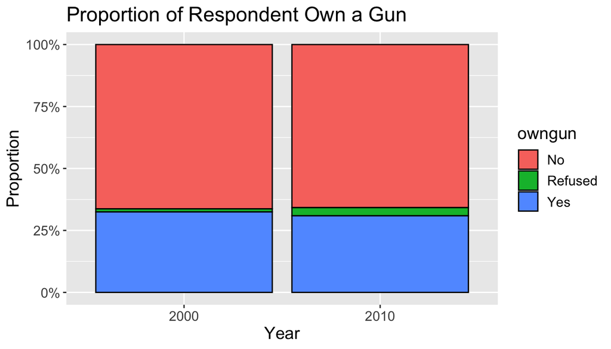

```r
ggplot(subset.data.1, aes(x=year, fill=owngun))+
  theme(text = element_text(size = 14)) +
  scale_y_continuous(labels = c("0%", "25%", "50%", "75%", "100%")) +
  labs(x = 'Year', y='Proportion') +
  ggtitle('Proportion of Respondent Own a Gun')+
  geom_bar(position='fill', color='black')
```

Based on the plot summarised the following findings:-

1. The proportion *do not own a gun* is **higher** than *own a gun* for both year.
2. The proportion for *own a gun* and *do not own a gun* for both year is almost **similar**.

## Part 4: Inference

A hypothesis test is carry out the dataset for year 2000 and 2010. Hypothesis test is used to assess the plausibility of a hypothesis by using as sample data. In this case the sample is data in year 2000 and 2010.

```
## Response variable: categorical (2 levels, success: Yes)
## Explanatory variable: categorical (3 levels)
## n_2000 = 1857, p_hat_2000 = 0.3247
## n_2010 = 1275, p_hat_2010 = 0.309
## H0: p_2000 =  p_2010
## HA: p_2000 > p_2010
## p_value = 0.1894
```

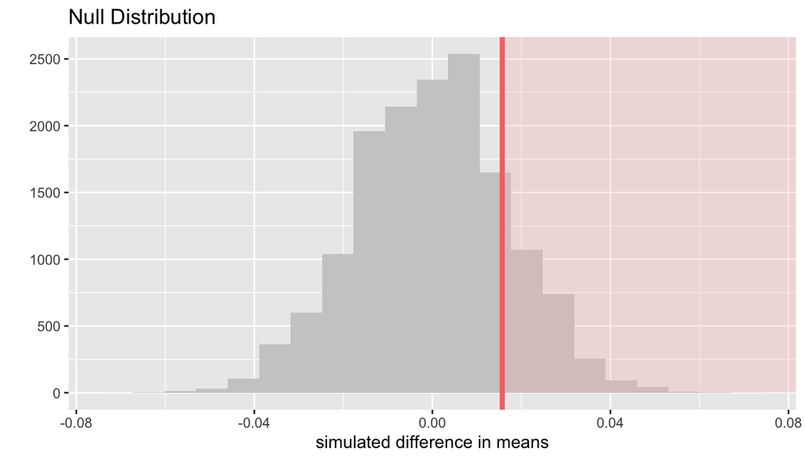

```r
inference(y = owngun,
          x = year,
          data=subset.data.1,
          type = "ht",
          statistic = "proportion",
          success = "Yes",
          method = "simulation",
          alternative = "greater",
          conf_level = 0.95,
          show_var_types = TRUE,
          show_summ_stats = TRUE,
          show_eda_plot = FALSE,
          show_inf_plot = TRUE,
          show_res = TRUE
          )
```